# 4 データを要約する

Published

2023/10/23

```r
#パッケージの読み込み
library(tidyverse) #様々な機能の統合パッケージ
library(magrittr) #コードを見やすくする
library(stargazer)
library(gtsummary)
```

# 1 データを要約する

膨大なデータの特徴を捉えるためには，代表的な値を使うといいです。

ここからは基本的に比例尺度を想定して

$$X_i = X_1, X_2,...X_n$$
とします。

## 1.1 平均値

データに含まれる値をすべて足してデータの数で割った値。$\bar X$ とすると。

$$\bar X = (X_1 + X_2 + ... X_n )/n = \frac{1}{n} \Sigma_{i=1}^{n} X_i$$

平均値は，統計的推測に際して重要な性質を持っていますが，データの真ん中を表しているわけではないことに注意が必要です。

```r
data3_1 <- c(100,90,80,70,60,40,10)
xbar <- mean(data3_1)
xbar

#これは以下でも同じ
xbar2 = sum(data3_1) / length(data3_1)
xbar2
```

**1**

データを作成して，`data3_1`という名前で保存

**2**

`sum()` は()内で指定したデータを合計する関数，`length()` はデータの数（行数）を吐き出す関数。`data3_1`は7行なので7が吐き出される。

```
[1] 64.28571
[1] 64.28571
```

## 1.2 中央値

データを順番に並べてちょうど真ん中の値。

```r
median(data3_1)
```

```
[1] 70
```

平均値と中央値はそれぞれデータの代表的な値ではありますが，必ずしも一致しません。例えば以下のようなデータがあったとします。

```r
x <- c(10, 10, 10, 10, 10, 10, 10, 20, 20, 30, 90, 100)
```

平均と中央値はそれぞれ違います。

```r
mean(x)
```

```
[1] 27.5
```

```r
median(x)
```

```
[1] 10
```

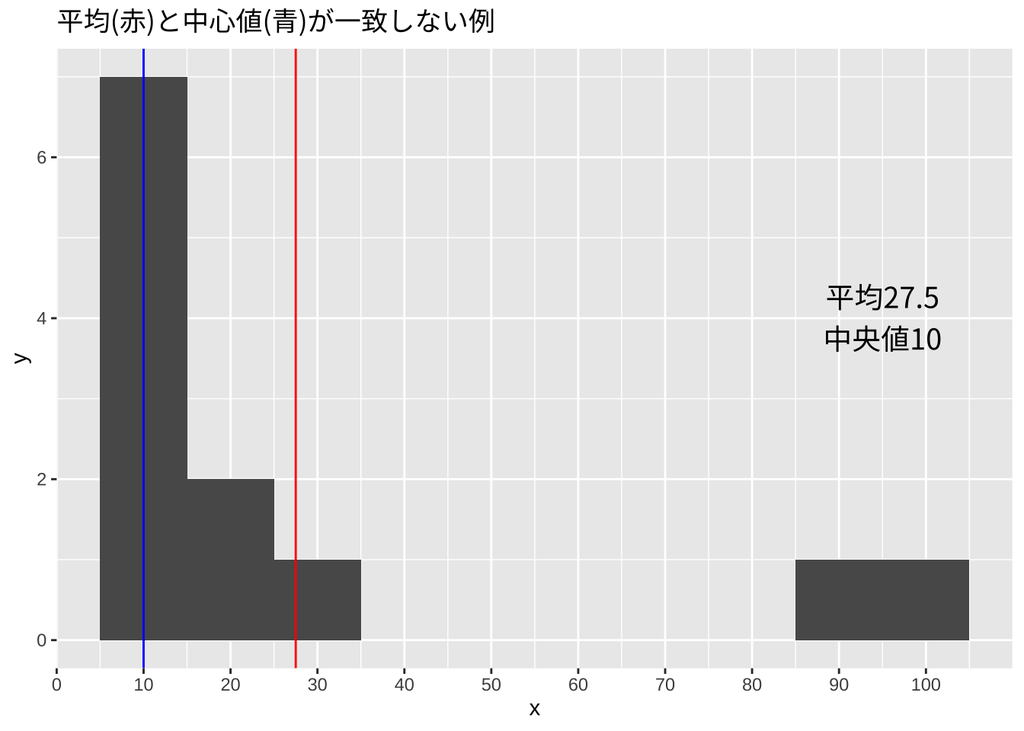

一致する場合もあります。

| value |
| --- |
| 0 |
| 10 |
| 20 |
| 20 |
| 30 |
| 30 |
| 30 |
| 40 |
| 40 |
| 40 |

[output cut: 17 more lines]

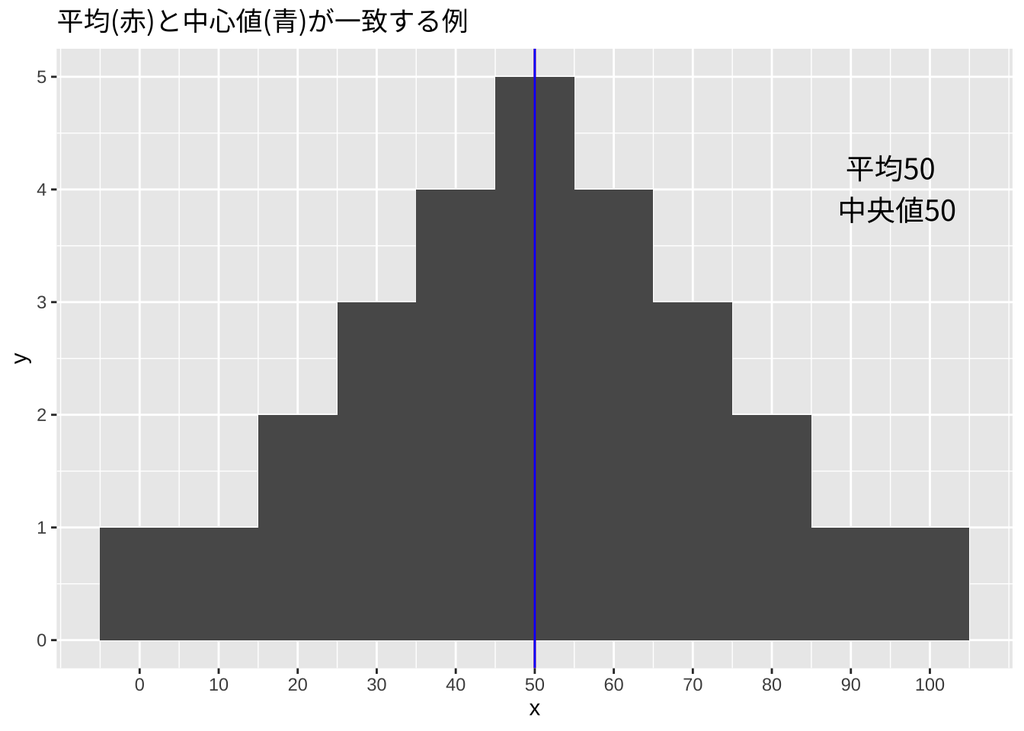

## 1.3 最大値・最小値

そのまま，最大の値と最小の値

```r
max(data3_1)
```

```
[1] 100
```

```r
min(data3_1)
```

```
[1] 10
```

## 1.4 分散

データのばらつき度合いを表します。例えば，A, Bという２つのクラスがあるとします。ある教科のテストの平均，中央値が両クラスとも60だったとしても，

1. 20,60,100,30,90
2. 60,60,60,60,60

というように特典の分布が全く異なる場合があり得ます。この違いは平均や中央値だけでは読み取れません。この違いを表す，平均からのばらつき度合いを把握する指標が分散です。

平均からの距離 （$\bar X - X_i$）は，プラスにもマイナスにもなり，足し合わせたら0になってしまうので，これを2乗した$(\bar X - X_i)^2$をデータの数だけ足し合わせて，データの数で割ったものを分散とします。

$$\text{分散} = \frac{1}{n} \Sigma_{i = 1}^n(\bar X - X_i)^2$$

```r
data3_2a <- c(20,60,100,30,90)
data3_2b <- c(60,60,60,60,60)

meana <- mean(data3_2a)
sa <- meana -　data3_2a
sua <- sum(sa^2)
分散a <- sua / length(data3_2a)

分散b = sum((mean(data3_2b) - data3_2b)^2)/length(data3_2b)

分散a
分散b
```

**1**

こんなふうに変数名は日本語でも大丈夫ですが，全角半角の切り替えが面倒くさかったり，ミスの元なのであまりやらない方がいいと思います。

```
[1] 1000
[1] 0
```

Aの分散は1000，Bの分散は0。

## 1.5 標準偏差

でも，この数値は何を意味しているのかがわからないです。なぜなら，元の点数（100点満点）を2乗しているからです。これをルートを取って元に戻すと，元の数値や平均値と同じ単位になります。分散のルートを取ったものを標準偏差といいます。

$$\text{標準偏差} = \sqrt{\text{分散}}$$

```r
標準偏差A <- sqrt(分散a)
標準偏差A
```

```
[1] 31.62278
```

# 2 データの可視化

名義尺度など，計算が不可能なものを要約し，可視化する方法として，度数分布表とヒストグラムがあります。

## 2.1 度数分布表

名義尺度や順序尺度（もしくは範囲を区切った量的変数）ごとに当てはまるサンプルサイズを集計した表です。

```r
data3 <- read_csv("data/data3.csv")
data3
table(data3$hometown)

data3 %>%
  select(.,hometown) %>%
  tbl_summary(.,
              label = list(hometown ~ ""),
              sort = list(everything() ~ "frequency")
              ) %>%
  modify_header(label = "")
```

**1**

`select()`でデータの中から出身地(`hometown`)を抜き出し

**2**

`tbl_summary()`でいい感じの表に

| id | class | gender | test | hometown |
| --- | --- | --- | --- | --- |
| 1 | 1 | 男 | 100 | 京都 |
| 2 | 1 | 女 | 20 | 京都 |
| 3 | 1 | 女 | 60 | 大阪 |
| 4 | 1 | 女 | 80 | 兵庫 |
| 5 | 1 | 男 | 40 | 兵庫 |
| 6 | 1 | 女 | 90 | 大阪 |
| 7 | 1 | 男 | 30 | 大阪 |
| 8 | 1 | 男 | 60 | 奈良 |
| 9 | 1 | 男 | 90 | 島根 |
| 10 | 1 | 女 | 30 | 兵庫 |

[output cut: 20 more lines]

```
  京都   兵庫 北海道   大阪   奈良   島根   滋賀
     7      6      1     10      3      1      2
```

|  | **N = 30**<sup>1</sup> |
| --- | --- |
| 大阪 | 10 (33%) |
| 京都 | 7 (23%) |
| 兵庫 | 6 (20%) |
| 奈良 | 3 (10%) |
| 滋賀 | 2 (6.7%) |
| 北海道 | 1 (3.3%) |
| 島根 | 1 (3.3%) |

<sup>1</sup> n (%)

## 2.2 ヒストグラム

特定のカテゴリごとの度数がわかるグラフです。例えばテストの点数なら，特定の範囲にどれぐらいの人がいるかがわかります。

```r
data3 %$%
  hist(test,
       breaks = seq(5,105,10),
       xaxt = "n"
       )
axis(1, at = 10*(0:100))
```

**1**

10点ごとの幅に

**2**

自動生成されるラベルを非表示に

**3**

ラベルの指定（０から100まで10刻みに）

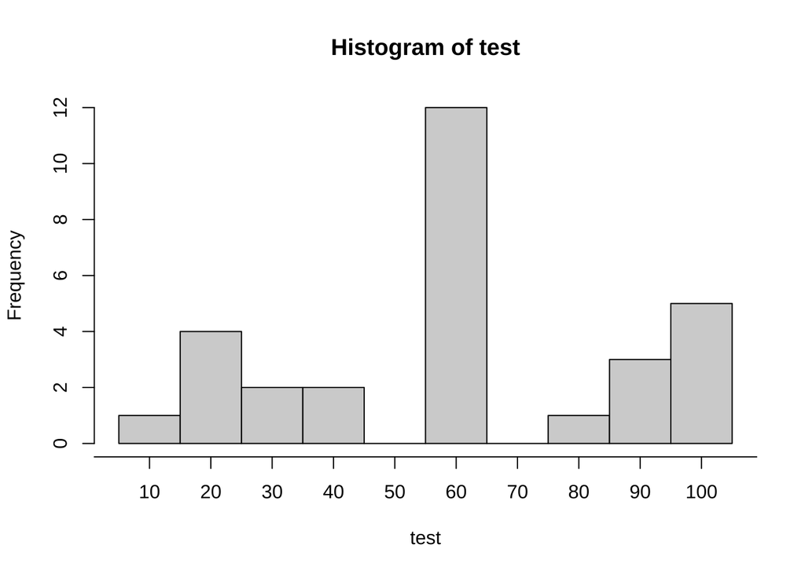

`ggplot2`というパッケージ(`tidyverse`に同梱)を使うと以下のように作成できます。この程度の単純な表だとggplotの方がややこしいですが，いろいろカスタマイズするにはこちらの方が良いらしいです。

```r
data3 %$%
  ggplot(., aes(test)) +
  geom_histogram(breaks = seq(5,105,10)) +
  scale_x_continuous(breaks=seq(0,100,10))
```

**1**

x軸の基準を指定

**2**

ヒストグラムを作成（10点刻み）

**3**

ラベルを作成(10点刻み)

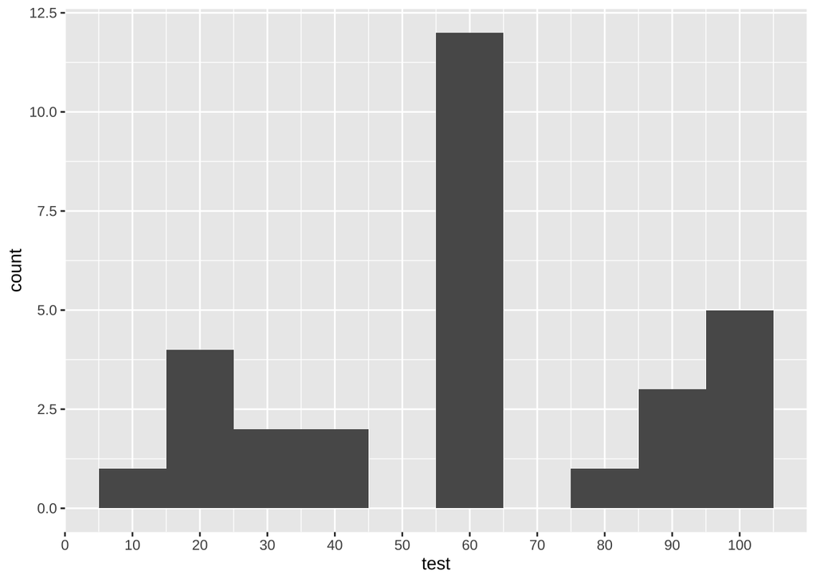

例えば，グループごとに色分けする

```r
data3 %<>% mutate(class = as.factor(class))

data3 %>%
  ggplot(., aes(test, fill = class)) +
  geom_histogram(breaks = seq(5,105,10)) +
  scale_x_continuous(breaks=seq(0,100,10))
```

**1**

fillで色分けしたいグループを指定

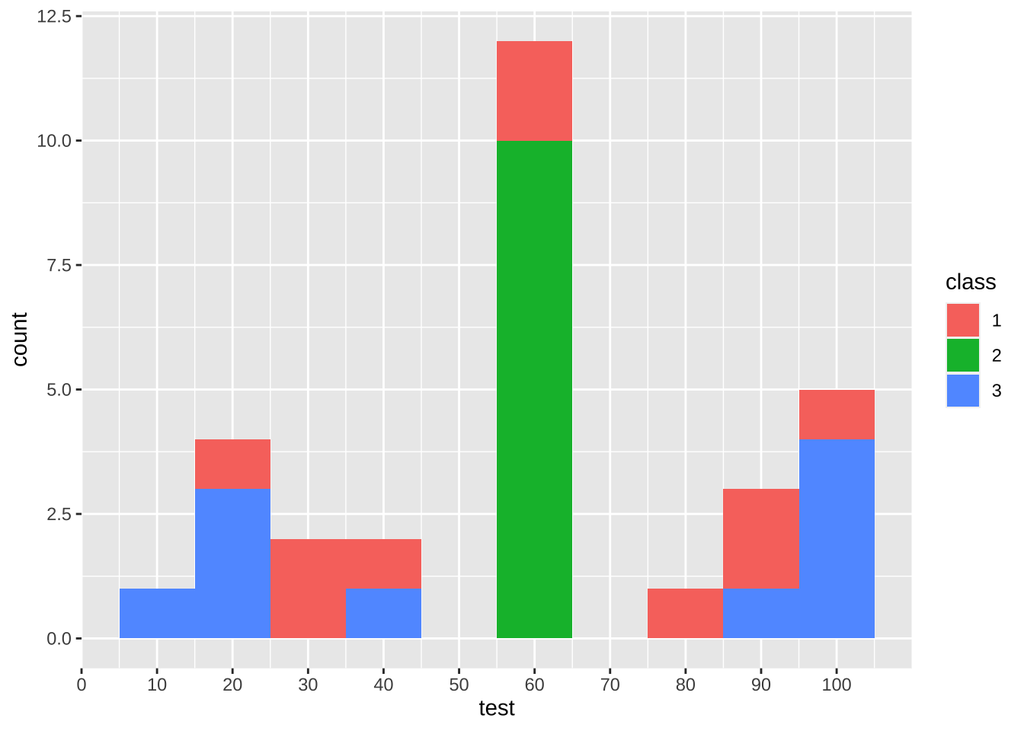

クラスごとに分けて作成

```r
data3 %$%
  ggplot(., aes(test)) +
  geom_histogram(breaks = seq(5,105,10)) +
  scale_x_continuous(breaks=seq(0,100,10)) +
  facet_grid(~class)
```

**1**

classごとに分けて表示

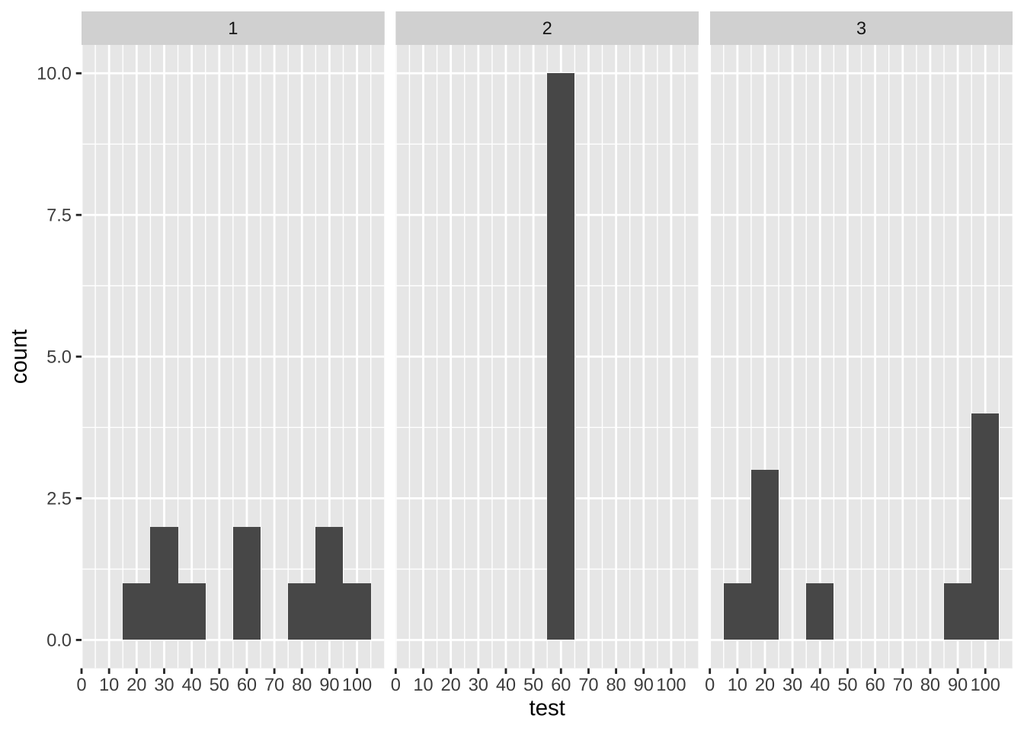

これだと，平均がどれも60点の3クラスだけど，得点のばらつき度合いが大きく違う，ということがわかりやすいです。

## 2.3 箱ひげ図

複数のグループごとの中央値やばらつき度合いを視覚的に表現できます。ここでは，クラスごとのテストの点数の箱ひげ図を書きます。

```r
data3 %$%
  boxplot(test~class)
```

**1**

`boxplot()`で箱ひげ図が書ける。()の中は`(表示したい数値 ~ 場合分けしたいカテゴリ変数)`

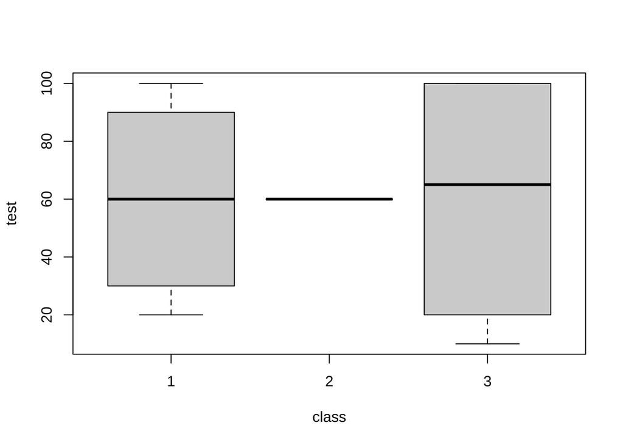

- 最も外の線は最大値と最小値，箱の上下はそれぞれ75％点と25％点，つまり上下4分の1の点，真ん中の太線は中央値です。
- クラス2は全員が60点だったので，箱がなく中央値の線だけが記載されています（箱が潰れて線になっているイメージ）

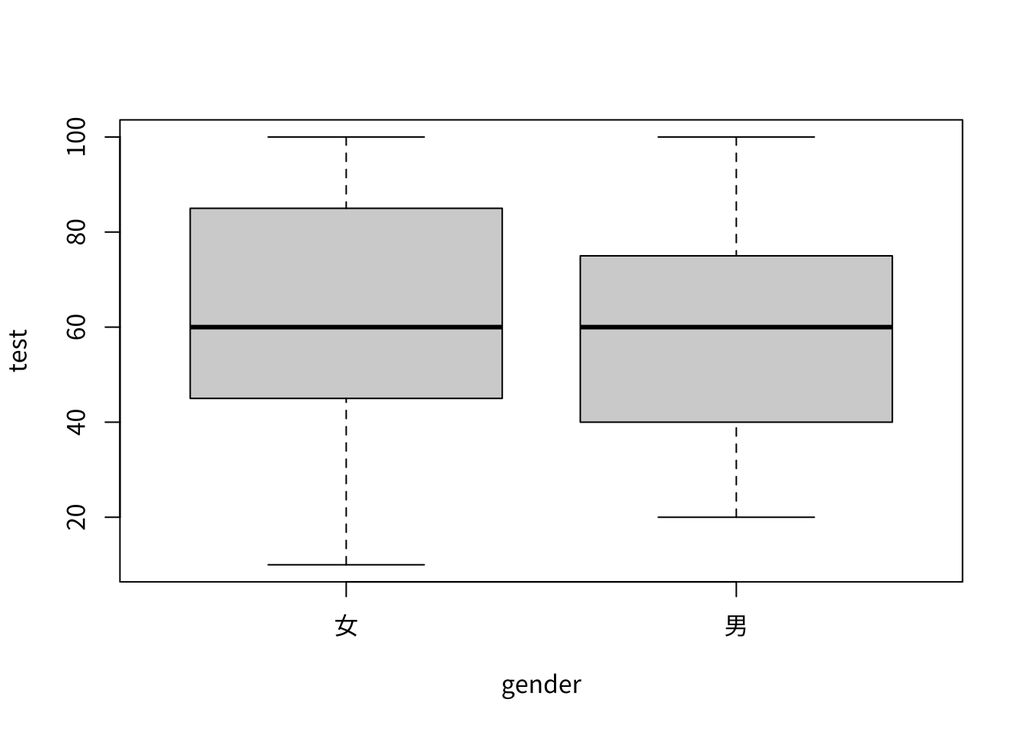

```r
par(family= "jp")
data3 %$%
  boxplot(test~gender)
```